```python
import pandas as pd
import numpy as np
import math
import matplotlib.pyplot as plt
import seaborn as sns
import sklearn
import os
```

# 米国干ばつ予測データセット - 探索的データ分析（EDA）

## 1. 問題設計の概要

このデータセットは、気象データのみを用いて米国の干ばつレベルを予測することを目的としています。

### 干ばつレベル

- **None**: 干ばつなし
- **D0**: 異常な乾燥（Abnormally Dry）
- **D1**: 中程度の干ばつ（Moderate Drought）
- **D2**: 重度の干ばつ（Severe Drought）
- **D3**: 極度の干ばつ（Extreme Drought）
- **D4**: 例外的な干ばつ（Exceptional Drought）

### 評価指標

- Macro F1平均
- MAE平均

## 2. データセットの基本情報

### データサイズとメモリ使用量

- **訓練データ**: 約1,930万行、4.2GB
- **検証データ**: 約227万行、491MB
- **テストデータ**: 約227万行、492MB
- **土壌データ**: 3,109行（各郡に1行）、0.76MB

### 欠損値の分析

- **scoreカラム**: 約85-87%が欠損（干ばつスコアは週次データ、気象データは日次データのため）
- **気象データ**: 欠損値なし
- **土壌データ**: 欠損値なし

```python
import pandas as pd

# Display CSV: dataset_basic_info.csv
df = pd.read_csv('/work/artifacts/dataset_basic_info.csv')
print(f"Shape: {df.shape}")
print(f"\nColumns: {list(df.columns)}")
print(f"\nFirst 10 rows:")
display(df.head(10))
```

```
Shape: (4, 6)

Columns: ['dataset', 'rows', 'columns', 'memory_mb', 'unique_fips', 'date_range']

First 10 rows:
```

|  | dataset | rows | columns | memory_mb | unique_fips | date_range |
| --- | --- | --- | --- | --- | --- | --- |
| 0 | train | 19300680 | 21 | 4178.289883 | 3108 | 2000-01-01 00:00:00 to 2016-12-31 00:00:00 |
| 1 | validation | 2268840 | 21 | 491.167843 | 3108 | 2017-01-01 00:00:00 to 2018-12-31 00:00:00 |
| 2 | test | 2271948 | 21 | 491.840675 | 3108 | 2019-01-01 00:00:00 to 2020-12-31 00:00:00 |
| 3 | soil | 3109 | 32 | 0.759159 | 3109 | NaN |

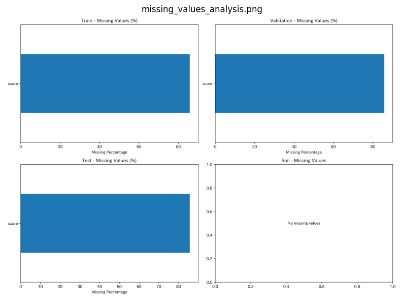

```python
import matplotlib.pyplot as plt
import matplotlib.image as mpimg

# Display image: missing_values_analysis.png
img = mpimg.imread('/work/artifacts/missing_values_analysis.png')
plt.figure(figsize=(10, 8))
plt.imshow(img)
plt.axis('off')
plt.title('missing_values_analysis.png')
plt.show()
```

## 3. 干ばつスコアの分布

### 重要な発見

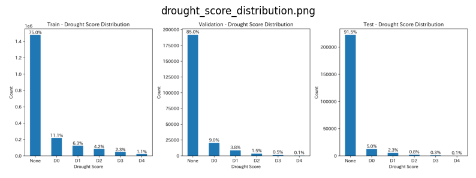

```python
import matplotlib.pyplot as plt
import matplotlib.image as mpimg

# Display image: drought_score_distribution.png
img = mpimg.imread('/work/artifacts/drought_score_distribution.png')
plt.figure(figsize=(10, 8))
plt.imshow(img)
plt.axis('off')
plt.title('drought_score_distribution.png')
plt.show()
```

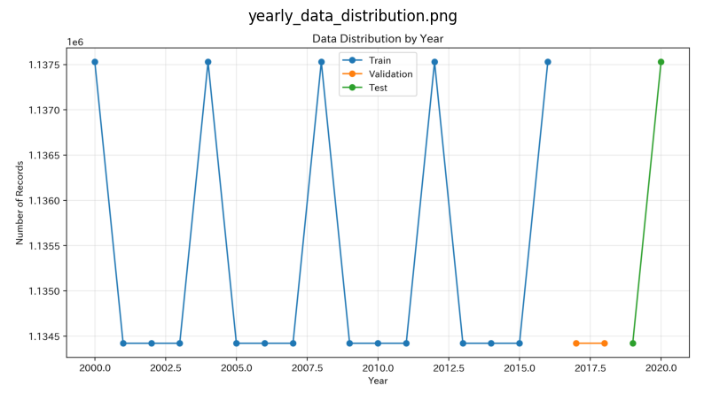

```python
import matplotlib.pyplot as plt
import matplotlib.image as mpimg

# Display image: yearly_data_distribution.png
img = mpimg.imread('/work/artifacts/yearly_data_distribution.png')
plt.figure(figsize=(10, 8))
plt.imshow(img)
plt.axis('off')
plt.title('yearly_data_distribution.png')
plt.show()
```

## 4. 気象データの基礎統計

### 主要な気象変数の統計量

- **降水量（PRECTOT）**: 平均2.64mm/日、最大234.59mm/日（極端な降雨イベント）
- **気温（T2M）**: 平均12.8°C、最小-37.34°C、最大41.39°C（大きな変動）
- **気圧（PS）**: 平均96.66kPa、比較的安定
- **風速（WS10M）**: 平均3.56m/s、最大23.69m/s
- **湿度（QV2M）**: 平均7.82g/kg

```python
import pandas as pd

# Display CSV: weather_basic_statistics.csv
df = pd.read_csv('/work/artifacts/weather_basic_statistics.csv')
print(f"Shape: {df.shape}")
print(f"\nColumns: {list(df.columns)}")
print(f"\nFirst 10 rows:")
display(df.head(10))
```

```
Shape: (8, 19)

Columns: ['Unnamed: 0', 'PRECTOT', 'PS', 'QV2M', 'T2M', 'T2MDEW', 'T2MWET', 'T2M_MAX', 'T2M_MIN', 'T2M_RANGE', 'TS', 'WS10M', 'WS10M_MAX', 'WS10M_MIN', 'WS10M_RANGE', 'WS50M', 'WS50M_MAX', 'WS50M_MIN', 'WS50M_RANGE']

First 10 rows:
```

|  | Unnamed: 0 | PRECTOT | PS | QV2M | T2M | T2MDEW | T2MWET | T2M_MAX | T2M_MIN | T2M_RANGE | TS | WS10M | WS10M_MAX | WS10M_MIN | WS10M_RANGE | WS50M | WS50M_MAX | WS50M_MIN | WS50M_RANGE |
| --- | --- | --- | --- | --- | --- | --- | --- | --- | --- | --- | --- | --- | --- | --- | --- | --- | --- | --- | --- |
| 0 | count | 1.930068e+07 | 1.930068e+07 | 1.930068e+07 | 1.930068e+07 | 1.930068e+07 | 1.930068e+07 | 1.930068e+07 | 1.930068e+07 | 1.930068e+07 | 1.930068e+07 | 1.930068e+07 | 1.930068e+07 | 1.930068e+07 | 1.930068e+07 | 1.930068e+07 | 1.930068e+07 | 1.930068e+07 | 1.930068e+07 |
| 1 | mean | 2.644145e+00 | 9.665578e+01 | 7.816178e+00 | 1.280146e+01 | 6.951072e+00 | 6.986916e+00 | 1.868141e+01 | 7.411665e+00 | 1.126974e+01 | 1.288900e+01 | 3.564013e+00 | 5.195993e+00 | 1.928879e+00 | 3.267113e+00 | 5.525151e+00 | 7.811798e+00 | 3.130077e+00 | 4.681721e+00 |
| 2 | std | 6.226305e+00 | 5.447994e+00 | 4.694305e+00 | 1.092674e+01 | 1.014551e+01 | 1.009116e+01 | 1.154487e+01 | 1.057680e+01 | 4.005165e+00 | 1.114961e+01 | 1.862297e+00 | 2.627969e+00 | 1.351713e+00 | 1.947028e+00 | 2.321549e+00 | 2.861210e+00 | 2.122751e+00 | 2.171263e+00 |
| 3 | min | 0.000000e+00 | 6.612000e+01 | 1.200000e-01 | -3.734000e+01 | -3.770000e+01 | -3.746000e+01 | -3.220000e+01 | -4.596000e+01 | 3.000000e-02 | -3.823000e+01 | 2.500000e-01 | 5.400000e-01 | 0.000000e+00 | 1.600000e-01 | 4.000000e-01 | 7.000000e-01 | 0.000000e+00 | 3.200000e-01 |
| 4 | 25% | 0.000000e+00 | 9.584000e+01 | 3.780000e+00 | 4.450000e+00 | -9.600000e-01 | -9.200000e-01 | 1.027000e+01 | -7.000000e-01 | 8.420000e+00 | 4.340000e+00 | 2.140000e+00 | 3.110000e+00 | 9.600000e-01 | 1.810000e+00 | 3.790000e+00 | 5.680000e+00 | 1.450000e+00 | 3.130000e+00 |
| 5 | 50% | 1.800000e-01 | 9.830000e+01 | 6.840000e+00 | 1.402000e+01 | 7.570000e+00 | 7.580000e+00 | 2.040000e+01 | 8.030000e+00 | 1.124000e+01 | 1.404000e+01 | 3.140000e+00 | 4.670000e+00 | 1.660000e+00 | 2.800000e+00 | 5.120000e+00 | 7.310000e+00 | 2.770000e+00 | 4.250000e+00 |
| 6 | 75% | 2.160000e+00 | 9.996000e+01 | 1.135000e+01 | 2.188000e+01 | 1.552000e+01 | 1.552000e+01 | 2.787000e+01 | 1.614000e+01 | 1.408000e+01 | 2.207000e+01 | 4.600000e+00 | 6.750000e+00 | 2.580000e+00 | 4.250000e+00 | 6.880000e+00 | 9.460000e+00 | 4.410000e+00 | 5.770000e+00 |
| 7 | max | 2.345900e+02 | 1.043200e+02 | 2.292000e+01 | 4.139000e+01 | 2.755000e+01 | 2.755000e+01 | 4.991000e+01 | 3.380000e+01 | 3.461000e+01 | 4.385000e+01 | 2.369000e+01 | 3.628000e+01 | 1.720000e+01 | 2.825000e+01 | 2.835000e+01 | 4.273000e+01 | 2.087000e+01 | 3.243000e+01 |

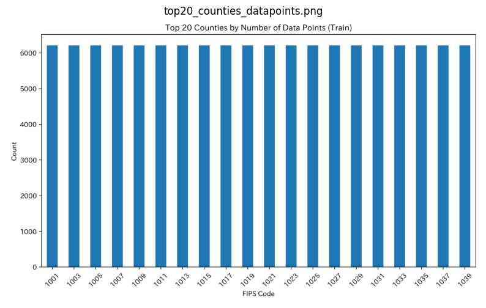

```python
import matplotlib.pyplot as plt
import matplotlib.image as mpimg

# Display image: top20_counties_datapoints.png
img = mpimg.imread('/work/artifacts/top20_counties_datapoints.png')
plt.figure(figsize=(10, 8))
plt.imshow(img)
plt.axis('off')
plt.title('top20_counties_datapoints.png')
plt.show()
```

## 5. 時系列データの特徴分析

### 気象変数の季節パターン

- **降水量**: 春から夏（4月～6月）に多く、秋冬に少ない
- **気温**: 夏（6月～8月）に高く、冬（12月～2月）に低い（典型的な季節変化）
- **湿度**: 夏に高く、冬に低い
- **風速**: 春に強く、夏から秋に弱い

### ラグ相関分析

- **降水量**: 負の相関（-0.024 to -0.093）- 降水が少ないと干ばつリスクが高まる
- **気温（T2M, T2M_MAX）**: 正の相関（最大0.21）- 高温が干ばつと関連
- **7日ラグでの気温の相関が最も強い**（0.21）

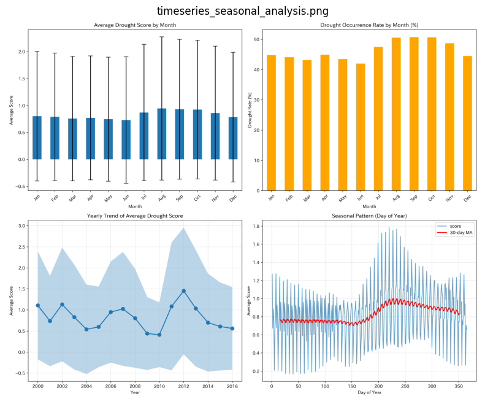

```python
import matplotlib.pyplot as plt
import matplotlib.image as mpimg

# Display image: timeseries_seasonal_analysis.png
img = mpimg.imread('/work/artifacts/timeseries_seasonal_analysis.png')
plt.figure(figsize=(10, 8))
plt.imshow(img)
plt.axis('off')
plt.title('timeseries_seasonal_analysis.png')
plt.show()
```

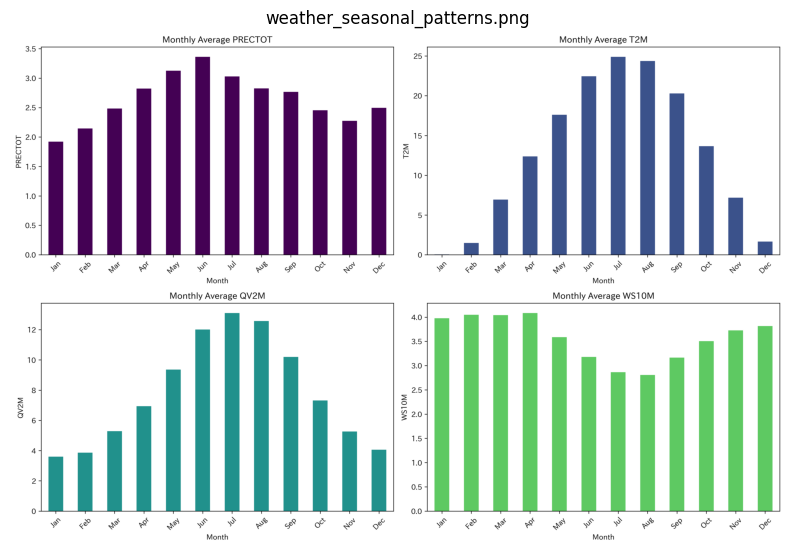

```python
import matplotlib.pyplot as plt
import matplotlib.image as mpimg

# Display image: weather_seasonal_patterns.png
img = mpimg.imread('/work/artifacts/weather_seasonal_patterns.png')
plt.figure(figsize=(10, 8))
plt.imshow(img)
plt.axis('off')
plt.title('weather_seasonal_patterns.png')
plt.show()
```

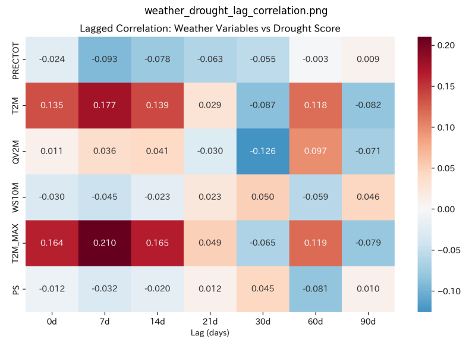

```python
import matplotlib.pyplot as plt
import matplotlib.image as mpimg

# Display image: weather_drought_lag_correlation.png
img = mpimg.imread('/work/artifacts/weather_drought_lag_correlation.png')
plt.figure(figsize=(10, 8))
plt.imshow(img)
plt.axis('off')
plt.title('weather_drought_lag_correlation.png')
plt.show()
```

## 6. 土壌データとの関連性分析

### 土壌品質指標

- **SQ1（栄養素の利用可能性）**: 値が高いほど干ばつスコアが低い
- **SQ2（栄養素保持能力）**: 値が高いほど干ばつスコアが低い
- **SQ5（過剰塩分）**: 値が高いほど干ばつスコアが高い

### 特徴量の重要度（ランダムフォレスト）

1. **経度（lon）**: 重要度スコア約0.55
2. **緯度（lat）**: 重要度スコア約0.35
3. **標高（elevation）**: 重要度スコア約0.08

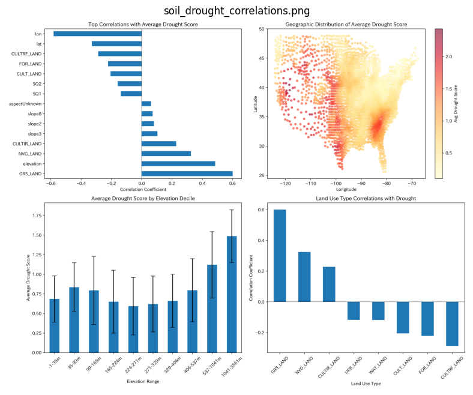

```python
import matplotlib.pyplot as plt
import matplotlib.image as mpimg

# Display image: soil_drought_correlations.png
img = mpimg.imread('/work/artifacts/soil_drought_correlations.png')
plt.figure(figsize=(10, 8))
plt.imshow(img)
plt.axis('off')
plt.title('soil_drought_correlations.png')
plt.show()
```

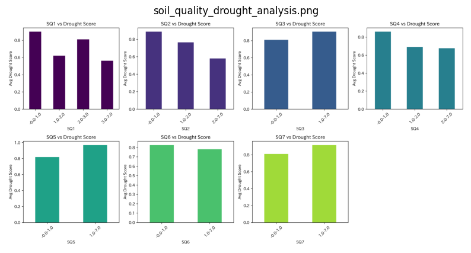

```python
import matplotlib.pyplot as plt
import matplotlib.image as mpimg

# Display image: soil_quality_drought_analysis.png
img = mpimg.imread('/work/artifacts/soil_quality_drought_analysis.png')
plt.figure(figsize=(10, 8))
plt.imshow(img)
plt.axis('off')
plt.title('soil_quality_drought_analysis.png')
plt.show()
```

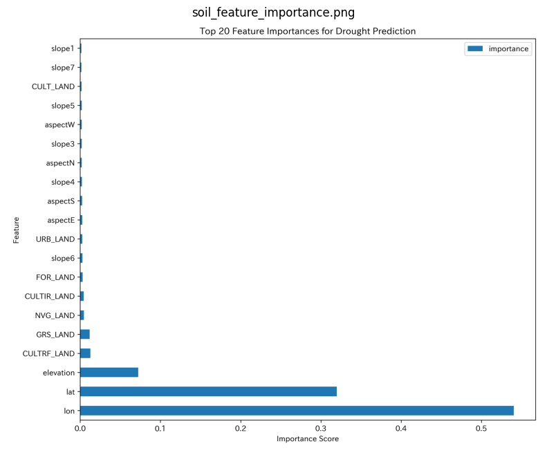

```python
import matplotlib.pyplot as plt
import matplotlib.image as mpimg

# Display image: soil_feature_importance.png
img = mpimg.imread('/work/artifacts/soil_feature_importance.png')
plt.figure(figsize=(10, 8))
plt.imshow(img)
plt.axis('off')
plt.title('soil_feature_importance.png')
plt.show()
```

## 7. 深掘り分析

### 地域別・季節別の干ばつパターン

1. **西部**: 年間通じて干ばつ率が高い（60-75%）
2. **中西部**: 夏から秋に干ばつが増加（最大55%）
3. **東部**: 年間通じて干ばつ率が低い（30-45%）

### 気温-降水量の組み合わせ効果

- **高温×少雨**: 最も高い干ばつスコア（1.14）
- **低温×多雨**: 最も低い干ばつスコア（0.56）
- 気温と降水量の相互作用が重要

### 土地利用タイプ別の季節変動

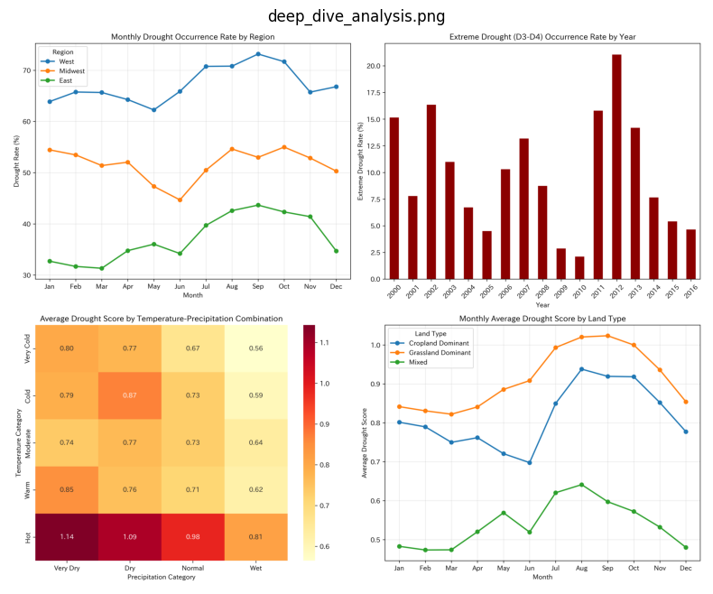

```python
import matplotlib.pyplot as plt
import matplotlib.image as mpimg

# Display image: deep_dive_analysis.png
img = mpimg.imread('/work/artifacts/deep_dive_analysis.png')
plt.figure(figsize=(10, 8))
plt.imshow(img)
plt.axis('off')
plt.title('deep_dive_analysis.png')
plt.show()
```

## 8. 極端な気象条件での干ばつ分析

### 極端な気象条件での干ばつ発生率

- **高温（90パーセンタイル以上）**: 約62%の干ばつ発生率
- **通常条件**: 約44%の干ばつ発生率
- 高温は干ばつの強い予測因子であることが確認された

### 地域別の気候特性と干ばつ率

1. **西部**
   - 低降水量（約1.7mm/日）
   - 高い干ばつ率（約65%）
2. **中西部**
   - 中程度の降水量（約2.4mm/日）
   - 中程度の干ばつ率（約50%）
3. **東部**
   - 高降水量（約3.1mm/日）
   - 低い干ばつ率（約38%）

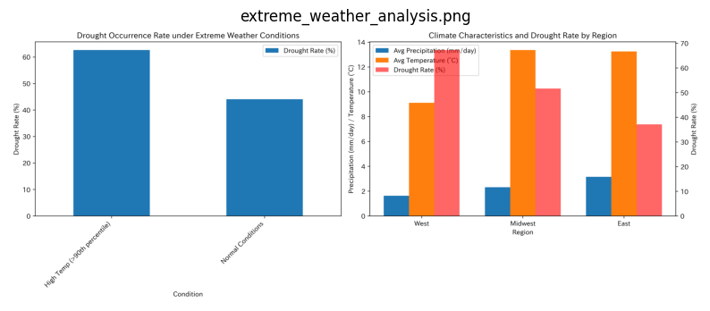

```python
import matplotlib.pyplot as plt
import matplotlib.image as mpimg

# Display image: extreme_weather_analysis.png
img = mpimg.imread('/work/artifacts/extreme_weather_analysis.png')
plt.figure(figsize=(10, 8))
plt.imshow(img)
plt.axis('off')
plt.title('extreme_weather_analysis.png')
plt.show()
```

## 9. 分析から得られた重要な示唆

### 推奨されるモデリングアプローチ

1. 地域別または緯度・経度でのモデル層別化
2. 時系列特徴量（移動平均、累積値、ラグ特徴量）の活用
3. 不均衡データ対策（SMOTE、クラス重み付け等）
4. 気象変数の交互作用項の追加
5. アンサンブル手法による予測の安定化

## 付録: 実行した分析コード

以下は、この分析で実行した主要な関数の実装です。

```python
# 基礎統計量、データサイズ、欠損値分析を実施
def basic_eda(train: pd.DataFrame, validation: pd.DataFrame, test: pd.DataFrame, soil: pd.DataFrame):
    """基礎統計量、データサイズ、欠損値分析を実施"""
    import matplotlib.pyplot as plt
    import seaborn as sns
    import os

    # 結果保存用のパスリスト
    artifact_paths = []
    output_dir = os.environ["ARTIFACT_DIR"]

    # 1. データセットの基本情報
    data_info = {
        'dataset': ['train', 'validation', 'test', 'soil'],
        'rows': [len(train), len(validation), len(test), len(soil)],
        'columns': [len(train.columns), len(validation.columns), len(test.columns), len(soil.columns)],
        'memory_mb': [
            train.memory_usage(deep=True).sum() / 1024**2,
            validation.memory_usage(deep=True).sum() / 1024**2,
            test.memory_usage(deep=True).sum() / 1024**2,
            soil.memory_usage(deep=True).sum() / 1024**2
        ],
        'unique_fips': [
            train['fips'].nunique(),
            validation['fips'].nunique(),
            test['fips'].nunique(),
            soil['fips'].nunique()
        ]
    }

    if 'date' in train.columns:
        data_info['date_range'] = [
            f"{pd.to_datetime(train['date']).min()} to {pd.to_datetime(train['date']).max()}",
            f"{pd.to_datetime(validation['date']).min()} to {pd.to_datetime(validation['date']).max()}",
            f"{pd.to_datetime(test['date']).min()} to {pd.to_datetime(test['date']).max()}",
            'N/A'
        ]

    info_df = pd.DataFrame(data_info)
    info_path = os.path.join(output_dir, "dataset_basic_info.csv")
    info_df.to_csv(info_path, index=False)
    artifact_paths.append(info_path)

    # 2. 欠損値分析
    fig, axes = plt.subplots(2, 2, figsize=(14, 10))
    datasets = [train, validation, test, soil]
    titles = ['Train', 'Validation', 'Test', 'Soil']

    for idx, (data, title, ax) in enumerate(zip(datasets, titles, axes.flatten())):
        missing = data.isnull().sum()
        missing_pct = (missing / len(data) * 100).sort_values(ascending=False)
        missing_pct = missing_pct[missing_pct > 0]

        if len(missing_pct) > 0:
            missing_pct.plot(kind='barh', ax=ax)
            ax.set_title(f'{title} - Missing Values (%)')
            ax.set_xlabel('Missing Percentage')
        else:
            ax.text(0.5, 0.5, 'No missing values', ha='center', va='center')
            ax.set_title(f'{title} - Missing Values')

    plt.tight_layout()
    missing_path = os.path.join(output_dir, "missing_values_analysis.png")
    plt.savefig(missing_path, dpi=300, bbox_inches='tight')
    plt.close()
    artifact_paths.append(missing_path)

    # 3. 干ばつスコアの分布（時系列データのみ）
    fig, axes = plt.subplots(1, 3, figsize=(15, 5))

    for data, title, ax in zip([train, validation, test], ['Train', 'Validation', 'Test'], axes):
        if 'score' in data.columns:
            # NaNではないスコアのみ取得
            valid_scores = data['score'].dropna()
            score_dist = valid_scores.value_counts().sort_index()

            # 0-5のスコア全てに対してプロット（データがない場合は0）
            all_scores = pd.Series([score_dist.get(i, 0) for i in range(6)], index=range(6))
            all_scores.plot(kind='bar', ax=ax)

            ax.set_title(f'{title} - Drought Score Distribution')
            ax.set_xlabel('Drought Score')
            ax.set_ylabel('Count')
            ax.set_xticklabels(['None', 'D0', 'D1', 'D2', 'D3', 'D4'], rotation=0)

            # パーセンテージを追加
            total = all_scores.sum()
            for i, v in enumerate(all_scores.values):
                if total > 0:
                    ax.text(i, v + 1000, f'{v/total:.1%}', ha='center', va='bottom')

    plt.tight_layout()
    score_dist_path = os.path.join(output_dir, "drought_score_distribution.png")
    plt.savefig(score_dist_path, dpi=300, bbox_inches='tight')
    plt.close()
    artifact_paths.append(score_dist_path)

    # 4. 気象データの基礎統計量（訓練データのみ）
    weather_cols = ['PRECTOT', 'PS', 'QV2M', 'T2M', 'T2MDEW', 'T2MWET', 'T2M_MAX',
                   'T2M_MIN', 'T2M_RANGE', 'TS', 'WS10M', 'WS10M_MAX', 'WS10M_MIN',
                   'WS10M_RANGE', 'WS50M', 'WS50M_MAX', 'WS50M_MIN', 'WS50M_RANGE']

    stats_df = train[weather_cols].describe()
    stats_path = os.path.join(output_dir, "weather_basic_statistics.csv")
    stats_df.to_csv(stats_path)
    artifact_paths.append(stats_path)

    # 5. 年別のデータ分布
    fig, ax = plt.subplots(figsize=(12, 6))

    for data, label in [(train, 'Train'), (validation, 'Validation'), (test, 'Test')]:
        if 'date' in data.columns:
            data_copy = data.copy()
            data_copy['date'] = pd.to_datetime(data_copy['date'])
            data_copy['year'] = data_copy['date'].dt.year
            yearly_counts = data_copy.groupby('year').size()
            yearly_counts.plot(label=label, marker='o', ax=ax)

    ax.set_title('Data Distribution by Year')
    ax.set_xlabel('Year')
    ax.set_ylabel('Number of Records')
    ax.legend()
    ax.grid(True, alpha=0.3)

    yearly_dist_path = os.path.join(output_dir, "yearly_data_distribution.png")
    plt.savefig(yearly_dist_path, dpi=300, bbox_inches='tight')
    plt.close()
    artifact_paths.append(yearly_dist_path)

    # 6. 郡別のデータポイント数（トップ20）
    fig, ax = plt.subplots(figsize=(10, 6))

    train_fips_counts = train['fips'].value_counts()
    top20_fips = train_fips_counts.head(20)
    top20_fips.plot(kind='bar', ax=ax)
    ax.set_title('Top 20 Counties by Number of Data Points (Train)')
    ax.set_xlabel('FIPS Code')
    ax.set_ylabel('Count')
    ax.set_xticklabels(ax.get_xticklabels(), rotation=45)

    plt.tight_layout()
    fips_dist_path = os.path.join(output_dir, "top20_counties_datapoints.png")
    plt.savefig(fips_dist_path, dpi=300, bbox_inches='tight')
    plt.close()
    artifact_paths.append(fips_dist_path)

    return artifact_paths
```

```python
# 時系列データの特徴分析：季節性、トレンド、変動性
def timeseries_analysis(df: pd.DataFrame):
    """時系列データの特徴分析：季節性、トレンド、変動性"""
    import matplotlib.pyplot as plt
    import seaborn as sns
    import os
    from datetime import datetime

    artifact_paths = []
    output_dir = os.environ["ARTIFACT_DIR"]

    # データの準備
    df['date'] = pd.to_datetime(df['date'])
    df['year'] = df['date'].dt.year
    df['month'] = df['date'].dt.month
    df['dayofyear'] = df['date'].dt.dayofyear

    # 1. 月別の干ばつスコア分布
    fig, axes = plt.subplots(2, 2, figsize=(15, 12))

    # 月別平均スコア
    monthly_scores = df.groupby('month')['score'].agg(['mean', 'std', 'count'])
    ax = axes[0, 0]
    monthly_scores['mean'].plot(kind='bar', ax=ax, yerr=monthly_scores['std'], capsize=5)
    ax.set_title('Average Drought Score by Month')
    ax.set_xlabel('Month')
    ax.set_ylabel('Average Score')
    ax.set_xticklabels(['Jan', 'Feb', 'Mar', 'Apr', 'May', 'Jun',
                       'Jul', 'Aug', 'Sep', 'Oct', 'Nov', 'Dec'], rotation=45)

    # 月別の干ばつ発生率（スコア > 0）
    ax = axes[0, 1]
    monthly_drought = df[df['score'].notna()].groupby('month').apply(
        lambda x: (x['score'] > 0).sum() / len(x) * 100
    )
    monthly_drought.plot(kind='bar', ax=ax, color='orange')
    ax.set_title('Drought Occurrence Rate by Month (%)')
    ax.set_xlabel('Month')
    ax.set_ylabel('Drought Rate (%)')
    ax.set_xticklabels(['Jan', 'Feb', 'Mar', 'Apr', 'May', 'Jun',
                       'Jul', 'Aug', 'Sep', 'Oct', 'Nov', 'Dec'], rotation=45)

    # 2. 年別トレンド
    ax = axes[1, 0]
    yearly_stats = df[df['score'].notna()].groupby('year')['score'].agg(['mean', 'std'])
    yearly_stats['mean'].plot(ax=ax, marker='o', linewidth=2, markersize=8)
    ax.fill_between(yearly_stats.index,
                    yearly_stats['mean'] - yearly_stats['std'],
                    yearly_stats['mean'] + yearly_stats['std'],
                    alpha=0.3)
    ax.set_title('Yearly Trend of Average Drought Score')
    ax.set_xlabel('Year')
    ax.set_ylabel('Average Score')
    ax.grid(True, alpha=0.3)

    # 3. 日付別（年内）の季節パターン
    ax = axes[1, 1]
    daily_pattern = df[df['score'].notna()].groupby('dayofyear')['score'].mean()
    daily_pattern.plot(ax=ax, alpha=0.7)

    # 30日移動平均でスムージング
    daily_pattern_smooth = daily_pattern.rolling(window=30, center=True).mean()
    daily_pattern_smooth.plot(ax=ax, color='red', linewidth=2, label='30-day MA')

    ax.set_title('Seasonal Pattern (Day of Year)')
    ax.set_xlabel('Day of Year')
    ax.set_ylabel('Average Score')
    ax.legend()
    ax.grid(True, alpha=0.3)

    plt.tight_layout()
    seasonal_path = os.path.join(output_dir, "timeseries_seasonal_analysis.png")
    plt.savefig(seasonal_path, dpi=300, bbox_inches='tight')
    plt.close()
    artifact_paths.append(seasonal_path)

    # 4. 気象変数の季節性分析
    weather_vars = ['PRECTOT', 'T2M', 'QV2M', 'WS10M']
    fig, axes = plt.subplots(2, 2, figsize=(15, 10))

    for idx, (var, ax) in enumerate(zip(weather_vars, axes.flatten())):
        monthly_var = df.groupby('month')[var].mean()
        monthly_var.plot(kind='bar', ax=ax, color=plt.cm.viridis(idx/len(weather_vars)))
        ax.set_title(f'Monthly Average {var}')
        ax.set_xlabel('Month')
        ax.set_ylabel(var)
        ax.set_xticklabels(['Jan', 'Feb', 'Mar', 'Apr', 'May', 'Jun',
                           'Jul', 'Aug', 'Sep', 'Oct', 'Nov', 'Dec'], rotation=45)

    plt.tight_layout()
    weather_seasonal_path = os.path.join(output_dir, "weather_seasonal_patterns.png")
    plt.savefig(weather_seasonal_path, dpi=300, bbox_inches='tight')
    plt.close()
    artifact_paths.append(weather_seasonal_path)

    # 5. 干ばつスコアと気象変数の時間遅れ相関
    # サンプリングして計算を高速化
    sample_fips = df['fips'].unique()[:100]  # 100郡のみ
    sampled_df = df[df['fips'].isin(sample_fips) & df['score'].notna()].copy()

    lag_corrs = []
    weather_vars = ['PRECTOT', 'T2M', 'QV2M', 'WS10M', 'T2M_MAX', 'PS']
    lags = [0, 7, 14, 21, 30, 60, 90]

    for var in weather_vars:
        var_corrs = []
        for lag in lags:
            # 各郡ごとにラグ相関を計算して平均
            corr_per_fips = []
            for fips in sample_fips:
                fips_data = sampled_df[sampled_df['fips'] == fips].sort_values('date')
                if len(fips_data) > lag + 10:  # 十分なデータがある場合のみ
                    lagged_var = fips_data[var].shift(lag)
                    corr = fips_data['score'].corr(lagged_var)
                    if not pd.isna(corr):
                        corr_per_fips.append(corr)

            if corr_per_fips:
                var_corrs.append(np.mean(corr_per_fips))
            else:
                var_corrs.append(0)

        lag_corrs.append(var_corrs)

    # 相関ヒートマップ
    fig, ax = plt.subplots(figsize=(10, 6))
    lag_corr_df = pd.DataFrame(lag_corrs, columns=[f'{lag}d' for lag in lags], index=weather_vars)
    sns.heatmap(lag_corr_df, annot=True, fmt='.3f', cmap='RdBu_r', center=0, ax=ax)
    ax.set_title('Lagged Correlation: Weather Variables vs Drought Score')
    ax.set_xlabel('Lag (days)')

    lag_corr_path = os.path.join(output_dir, "weather_drought_lag_correlation.png")
    plt.savefig(lag_corr_path, dpi=300, bbox_inches='tight')
    plt.close()
    artifact_paths.append(lag_corr_path)

    # 6. 統計サマリーの保存
    summary_stats = {
        'monthly_avg_score': monthly_scores['mean'].to_dict(),
        'yearly_trend': yearly_stats['mean'].to_dict(),
        'peak_drought_months': monthly_drought.nlargest(3).to_dict(),
        'lowest_drought_months': monthly_drought.nsmallest(3).to_dict()
    }

    summary_path = os.path.join(output_dir, "timeseries_summary_stats.csv")
    pd.DataFrame([summary_stats]).to_csv(summary_path, index=False)
    artifact_paths.append(summary_path)

    return artifact_paths
```

```python
# 土壌データと干ばつの関連性分析
def soil_drought_relationship(train: pd.DataFrame, validation: pd.DataFrame, test: pd.DataFrame, soil: pd.DataFrame):
    """土壌データと干ばつの関連性分析"""
    import matplotlib.pyplot as plt
    import seaborn as sns
    import os
    from scipy import stats

    artifact_paths = []
    output_dir = os.environ["ARTIFACT_DIR"]

    # 訓練データと土壌データを結合
    train_with_soil = train.merge(soil, on='fips', how='left')

    # 郡ごとの干ばつ統計を計算
    county_drought_stats = train[train['score'].notna()].groupby('fips').agg({
        'score': ['mean', 'std', 'count'],
        'PRECTOT': 'mean',
        'T2M': 'mean'
    }).reset_index()
    county_drought_stats.columns = ['fips', 'avg_drought_score', 'std_drought_score',
                                   'count_records', 'avg_precip', 'avg_temp']

    # 土壌データと結合
    county_stats_with_soil = county_drought_stats.merge(soil, on='fips', how='left')

    # 1. 地理的要因と干ばつスコアの相関
    geo_features = ['lat', 'lon', 'elevation']
    slope_features = [f'slope{i}' for i in range(1, 9)]
    aspect_features = ['aspectN', 'aspectE', 'aspectS', 'aspectW', 'aspectUnknown']
    land_features = ['WAT_LAND', 'NVG_LAND', 'URB_LAND', 'GRS_LAND', 'FOR_LAND',
                    'CULTRF_LAND', 'CULTIR_LAND', 'CULT_LAND']
    soil_quality = ['SQ1', 'SQ2', 'SQ3', 'SQ4', 'SQ5', 'SQ6', 'SQ7']

    all_features = geo_features + slope_features + aspect_features + land_features + soil_quality

    # 相関行列の計算
    corr_data = county_stats_with_soil[['avg_drought_score'] + all_features].corr()

    # 最も相関の高い特徴量を抽出
    drought_corrs = corr_data['avg_drought_score'].drop('avg_drought_score').sort_values(ascending=False)

    # 2. 相関の可視化
    fig, axes = plt.subplots(2, 2, figsize=(15, 12))

    # トップ15の相関を表示
    ax = axes[0, 0]
    top_corrs = pd.concat([drought_corrs.head(8), drought_corrs.tail(7)])
    top_corrs.plot(kind='barh', ax=ax)
    ax.set_title('Top Correlations with Average Drought Score')
    ax.set_xlabel('Correlation Coefficient')
    ax.axvline(x=0, color='black', linestyle='-', linewidth=0.5)

    # 3. 地理的分布
    ax = axes[0, 1]
    scatter = ax.scatter(county_stats_with_soil['lon'],
                        county_stats_with_soil['lat'],
                        c=county_stats_with_soil['avg_drought_score'],
                        cmap='YlOrRd', alpha=0.6, s=20)
    ax.set_title('Geographic Distribution of Average Drought Score')
    ax.set_xlabel('Longitude')
    ax.set_ylabel('Latitude')
    plt.colorbar(scatter, ax=ax, label='Avg Drought Score')

    # 4. 標高と干ばつの関係
    ax = axes[1, 0]
    # 標高をビンに分割
    elevation_bins = pd.qcut(county_stats_with_soil['elevation'], q=10, duplicates='drop')
    elevation_drought = county_stats_with_soil.groupby(elevation_bins)['avg_drought_score'].agg(['mean', 'std', 'count'])

    elevation_drought['mean'].plot(kind='bar', ax=ax, yerr=elevation_drought['std'], capsize=5)
    ax.set_title('Average Drought Score by Elevation Decile')
    ax.set_xlabel('Elevation Range')
    ax.set_ylabel('Average Drought Score')
    ax.set_xticklabels([f'{int(interval.left)}-{int(interval.right)}m'
                       for interval in elevation_drought.index], rotation=45)

    # 5. 土地利用タイプ別の干ばつ傾向
    ax = axes[1, 1]
    land_use_corrs = drought_corrs[land_features].sort_values(ascending=False)
    land_use_corrs.plot(kind='bar', ax=ax)
    ax.set_title('Land Use Type Correlations with Drought')
    ax.set_xlabel('Land Use Type')
    ax.set_ylabel('Correlation Coefficient')
    ax.axhline(y=0, color='black', linestyle='-', linewidth=0.5)
    ax.set_xticklabels(ax.get_xticklabels(), rotation=45)

    plt.tight_layout()
    soil_corr_path = os.path.join(output_dir, "soil_drought_correlations.png")
    plt.savefig(soil_corr_path, dpi=300, bbox_inches='tight')
    plt.close()
    artifact_paths.append(soil_corr_path)

    # 6. 土壌品質指標の分析
    fig, axes = plt.subplots(2, 4, figsize=(16, 8))
    axes = axes.flatten()

    for idx, sq in enumerate(soil_quality):
        ax = axes[idx]
        # 土壌品質指標をビンに分割
        sq_bins = pd.qcut(county_stats_with_soil[sq], q=5, duplicates='drop')
        sq_drought = county_stats_with_soil.groupby(sq_bins)['avg_drought_score'].mean()

        sq_drought.plot(kind='bar', ax=ax, color=plt.cm.viridis(idx/7))
        ax.set_title(f'{sq} vs Drought Score')
        ax.set_xlabel(sq)
        ax.set_ylabel('Avg Drought Score')
        ax.set_xticklabels([f'{interval.left:.1f}-{interval.right:.1f}'
                           for interval in sq_drought.index], rotation=45)

    # 最後の軸を非表示
    axes[-1].set_visible(False)

    plt.tight_layout()
    soil_quality_path = os.path.join(output_dir, "soil_quality_drought_analysis.png")
    plt.savefig(soil_quality_path, dpi=300, bbox_inches='tight')
    plt.close()
    artifact_paths.append(soil_quality_path)

    # 7. 特徴量の重要度ランキング（回帰分析）
    from sklearn.ensemble import RandomForestRegressor
    from sklearn.preprocessing import StandardScaler

    # 欠損値を処理
    feature_data = county_stats_with_soil[all_features].fillna(county_stats_with_soil[all_features].mean())
    target = county_stats_with_soil['avg_drought_score']

    # ランダムフォレストで特徴量の重要度を計算
    rf = RandomForestRegressor(n_estimators=100, random_state=42)
    rf.fit(feature_data, target)

    feature_importance = pd.DataFrame({
        'feature': all_features,
        'importance': rf.feature_importances_
    }).sort_values('importance', ascending=False)

    # 上位20の特徴量を可視化
    fig, ax = plt.subplots(figsize=(10, 8))
    feature_importance.head(20).plot(x='feature', y='importance', kind='barh', ax=ax)
    ax.set_title('Top 20 Feature Importances for Drought Prediction')
    ax.set_xlabel('Importance Score')
    ax.set_ylabel('Feature')

    plt.tight_layout()
    importance_path = os.path.join(output_dir, "soil_feature_importance.png")
    plt.savefig(importance_path, dpi=300, bbox_inches='tight')
    plt.close()
    artifact_paths.append(importance_path)

    # 8. 統計サマリーの保存
    summary_stats = {
        'top_positive_correlations': drought_corrs.head(5).to_dict(),
        'top_negative_correlations': drought_corrs.tail(5).to_dict(),
        'top_5_important_features': feature_importance.head(5).to_dict('records'),
        'r2_score': rf.score(feature_data, target)
    }

    summary_path = os.path.join(output_dir, "soil_analysis_summary.csv")
    pd.DataFrame([summary_stats]).to_csv(summary_path, index=False)
    artifact_paths.append(summary_path)

    return artifact_paths
```

```python
# 重要な発見に基づく深掘り分析
def deep_dive_analysis(train: pd.DataFrame, validation: pd.DataFrame, test: pd.DataFrame, soil: pd.DataFrame):
    """重要な発見に基づく深掘り分析"""
    import matplotlib.pyplot as plt
    import seaborn as sns
    import os

    artifact_paths = []
    output_dir = os.environ["ARTIFACT_DIR"]

    # データの準備
    train_with_soil = train.merge(soil, on='fips', how='left')
    train_with_soil['date'] = pd.to_datetime(train_with_soil['date'])
    train_with_soil['month'] = train_with_soil['date'].dt.month
    train_with_soil['year'] = train_with_soil['date'].dt.year

    # 1. 地域別・季節別の干ばつパターン分析
    # 西部、中西部、東部に分類
    train_with_soil['region'] = pd.cut(train_with_soil['lon'],
                                       bins=[-130, -105, -90, -65],
                                       labels=['West', 'Midwest', 'East'])

    fig, axes = plt.subplots(2, 2, figsize=(15, 12))

    # 地域別・月別の干ばつ発生率
    ax = axes[0, 0]
    region_month_drought = train_with_soil[train_with_soil['score'].notna()].groupby(['region', 'month']).apply(
        lambda x: (x['score'] > 0).sum() / len(x) * 100
    ).unstack()

    region_month_drought.T.plot(ax=ax, marker='o', linewidth=2)
    ax.set_title('Monthly Drought Occurrence Rate by Region')
    ax.set_xlabel('Month')
    ax.set_ylabel('Drought Rate (%)')
    ax.set_xticks(range(1, 13))
    ax.set_xticklabels(['Jan', 'Feb', 'Mar', 'Apr', 'May', 'Jun',
                       'Jul', 'Aug', 'Sep', 'Oct', 'Nov', 'Dec'])
    ax.legend(title='Region')
    ax.grid(True, alpha=0.3)

    # 2. 極端な干ばつ（D3-D4）の地理的・時間的パターン
    ax = axes[0, 1]
    extreme_drought = train_with_soil[(train_with_soil['score'] >= 3) & train_with_soil['score'].notna()]

    # 年別の極端な干ばつ発生頻度
    yearly_extreme = extreme_drought.groupby('year').size()
    yearly_total = train_with_soil[train_with_soil['score'].notna()].groupby('year').size()
    yearly_extreme_rate = (yearly_extreme / yearly_total * 100).fillna(0)

    yearly_extreme_rate.plot(ax=ax, kind='bar', color='darkred')
    ax.set_title('Extreme Drought (D3-D4) Occurrence Rate by Year')
    ax.set_xlabel('Year')
    ax.set_ylabel('Extreme Drought Rate (%)')
    ax.set_xticklabels(ax.get_xticklabels(), rotation=45)

    # 3. 気温-降水量の組み合わせと干ばつの関係
    ax = axes[1, 0]

    # サンプリングして計算を高速化
    sample_data = train_with_soil[train_with_soil['score'].notna()].sample(n=50000, random_state=42)

    # 気温と降水量をビンに分割（固定ビンを使用）
    temp_percentiles = sample_data['T2M'].quantile([0, 0.2, 0.4, 0.6, 0.8, 1.0])
    precip_percentiles = sample_data['PRECTOT'].quantile([0, 0.2, 0.4, 0.6, 0.8, 1.0])

    temp_bins = pd.cut(sample_data['T2M'], bins=temp_percentiles.unique(),
                      labels=['Very Cold', 'Cold', 'Moderate', 'Warm', 'Hot'][:len(temp_percentiles.unique())-1])
    precip_bins = pd.cut(sample_data['PRECTOT'], bins=precip_percentiles.unique(),
                        labels=['Very Dry', 'Dry', 'Normal', 'Wet', 'Very Wet'][:len(precip_percentiles.unique())-1])

    # クロス集計
    valid_data = sample_data[temp_bins.notna() & precip_bins.notna()]
    drought_by_temp_precip = valid_data.groupby([temp_bins[valid_data.index],
                                                 precip_bins[valid_data.index]])['score'].mean()
    drought_pivot = drought_by_temp_precip.unstack()

    if not drought_pivot.empty:
        sns.heatmap(drought_pivot, annot=True, fmt='.2f', cmap='YlOrRd', ax=ax)
        ax.set_title('Average Drought Score by Temperature-Precipitation Combination')
        ax.set_xlabel('Precipitation Category')
        ax.set_ylabel('Temperature Category')

    # 4. 土地利用変化の影響（草地vs耕作地の比較）
    ax = axes[1, 1]

    # 草地と耕作地の割合でカテゴリ分け
    train_with_soil['land_type'] = 'Mixed'
    train_with_soil.loc[train_with_soil['GRS_LAND'] > 0.5, 'land_type'] = 'Grassland Dominant'
    train_with_soil.loc[train_with_soil['CULT_LAND'] > 0.5, 'land_type'] = 'Cropland Dominant'

    land_drought = train_with_soil[train_with_soil['score'].notna()].groupby(['land_type', 'month']).apply(
        lambda x: x['score'].mean()
    ).unstack()

    land_drought.T.plot(ax=ax, marker='o', linewidth=2)
    ax.set_title('Monthly Average Drought Score by Land Type')
    ax.set_xlabel('Month')
    ax.set_ylabel('Average Drought Score')
    ax.set_xticks(range(1, 13))
    ax.set_xticklabels(['Jan', 'Feb', 'Mar', 'Apr', 'May', 'Jun',
                       'Jul', 'Aug', 'Sep', 'Oct', 'Nov', 'Dec'])
    ax.legend(title='Land Type')
    ax.grid(True, alpha=0.3)

    plt.tight_layout()
    deep_dive_path = os.path.join(output_dir, "deep_dive_analysis.png")
    plt.savefig(deep_dive_path, dpi=300, bbox_inches='tight')
    plt.close()
    artifact_paths.append(deep_dive_path)

    # 5. 気象パターンの極値分析
    fig, axes = plt.subplots(1, 2, figsize=(15, 6))

    # 極端な気象条件での干ばつ発生率
    ax = axes[0]

    # 極端な条件を定義
    extreme_conditions = {
        'High Temp (>90th percentile)': sample_data['T2M'] > sample_data['T2M'].quantile(0.9),
        'Low Precip (<10th percentile)': sample_data['PRECTOT'] < sample_data['PRECTOT'].quantile(0.1),
        'Both Extremes': (sample_data['T2M'] > sample_data['T2M'].quantile(0.9)) &
                        (sample_data['PRECTOT'] < sample_data['PRECTOT'].quantile(0.1)),
        'Normal Conditions': (sample_data['T2M'].between(sample_data['T2M'].quantile(0.4),
                                                        sample_data['T2M'].quantile(0.6))) &
                           (sample_data['PRECTOT'].between(sample_data['PRECTOT'].quantile(0.4),
                                                           sample_data['PRECTOT'].quantile(0.6)))
    }

    extreme_drought_rates = []
    for condition_name, condition_mask in extreme_conditions.items():
        condition_data = sample_data[condition_mask]
        if len(condition_data) > 0:
            drought_rate = (condition_data['score'] > 0).sum() / len(condition_data) * 100
            avg_score = condition_data['score'].mean()
            extreme_drought_rates.append({
                'Condition': condition_name,
                'Drought Rate (%)': drought_rate,
                'Avg Score': avg_score
            })

    extreme_df = pd.DataFrame(extreme_drought_rates)
    extreme_df.set_index('Condition')[['Drought Rate (%)']].plot(kind='bar', ax=ax)
    ax.set_title('Drought Occurrence Rate under Extreme Weather Conditions')
    ax.set_ylabel('Drought Rate (%)')
    ax.set_xticklabels(ax.get_xticklabels(), rotation=45, ha='right')

    # 地域別の気候特性
    ax = axes[1]
    climate_by_region = train_with_soil.groupby('region').agg({
        'PRECTOT': 'mean',
        'T2M': 'mean',
        'score': lambda x: (x > 0).sum() / x.notna().sum() * 100 if x.notna().sum() > 0 else 0
    })

    x = np.arange(len(climate_by_region))
    width = 0.25

    ax2 = ax.twinx()

    bar1 = ax.bar(x - width, climate_by_region['PRECTOT'], width, label='Avg Precipitation (mm/day)')
    bar2 = ax.bar(x, climate_by_region['T2M'], width, label='Avg Temperature (°C)')
    bar3 = ax2.bar(x + width, climate_by_region['score'], width, label='Drought Rate (%)', color='red', alpha=0.6)

    ax.set_xlabel('Region')
    ax.set_ylabel('Precipitation (mm/day) / Temperature (°C)')
    ax2.set_ylabel('Drought Rate (%)')
    ax.set_title('Climate Characteristics and Drought Rate by Region')
    ax.set_xticks(x)
    ax.set_xticklabels(climate_by_region.index)

    lines1, labels1 = ax.get_legend_handles_labels()
    lines2, labels2 = ax2.get_legend_handles_labels()
    ax.legend(lines1 + lines2, labels1 + labels2, loc='upper left')

    plt.tight_layout()
    extreme_analysis_path = os.path.join(output_dir, "extreme_weather_analysis.png")
    plt.savefig(extreme_analysis_path, dpi=300, bbox_inches='tight')
    plt.close()
    artifact_paths.append(extreme_analysis_path)

    return artifact_paths
```

## 付録: 必要なライブラリのインポート

分析を実行する前に、以下のライブラリをインポートしてください：

```python
# 必要なライブラリのインポート
import pandas as pd
import numpy as np
import matplotlib.pyplot as plt
import seaborn as sns
from sklearn.ensemble import RandomForestRegressor
from sklearn.preprocessing import StandardScaler
from scipy import stats
import os

# プロット設定
plt.style.use('default')
sns.set_palette("husl")
```